# Wrangle_act

## We Rate Dogs - Wrangling Data Project

### Step 1: Data Gathering

Create folder named **WeRateDog1**

```python
import os
folder_name='WeRateDog1'
if not os.path.exists('folder_name'):
    os.makedirs(folder_name)
```

Get content from "**image-predictions.tsv**" file and save it to the local folder **WeRateDog1** :

```python
url='https://d17h27t6h515a5.cloudfront.net/topher/2017/August/599fd2ad_image-predictions/image-predictions.tsv'
```

```python
import requests
with open (os.path.join(folder_name,url.split('/')[-1]),'wb') as file:
    r= requests.get(url)
    file.write(r.content)
```

```python
import pandas as pd
image_predictions=pd.read_csv('C:\\Users\\clair\\WeRateDog1\\image-predictions.tsv',sep='\t')
image_predictions.head()
```

|  | tweet_id | jpg_url | img_num | p1 | p1_conf | p1_dog | p2 | p2_conf | p2_dog | p3 | p3_conf | p3_dog |
| --- | --- | --- | --- | --- | --- | --- | --- | --- | --- | --- | --- | --- |
| 0 | 666020888022790149 | https://pbs.twimg.com/media/CT4udn0WwAA0aMy.jpg | 1 | Welsh_springer_spaniel | 0.465074 | True | collie | 0.156665 | True | Shetland_sheepdog | 0.061428 | True |
| 1 | 666029285002620928 | https://pbs.twimg.com/media/CT42GRgUYAA5iDo.jpg | 1 | redbone | 0.506826 | True | miniature_pinscher | 0.074192 | True | Rhodesian_ridgeback | 0.072010 | True |
| 2 | 666033412701032449 | https://pbs.twimg.com/media/CT4521TWwAEvMyu.jpg | 1 | German_shepherd | 0.596461 | True | malinois | 0.138584 | True | bloodhound | 0.116197 | True |
| 3 | 666044226329800704 | https://pbs.twimg.com/media/CT5Dr8HUEAA-lEu.jpg | 1 | Rhodesian_ridgeback | 0.408143 | True | redbone | 0.360687 | True | miniature_pinscher | 0.222752 | True |
| 4 | 666049248165822465 | https://pbs.twimg.com/media/CT5IQmsXIAAKY4A.jpg | 1 | miniature_pinscher | 0.560311 | True | Rottweiler | 0.243682 | True | Doberman | 0.154629 | True |

```python
image_predictions.sample(5)
```

|  | tweet_id | jpg_url | img_num | p1 | p1_conf | p1_dog | p2 | p2_conf | p2_dog | p3 | p3_conf | p3_dog |
| --- | --- | --- | --- | --- | --- | --- | --- | --- | --- | --- | --- | --- |
| 1074 | 717009362452090881 | https://pbs.twimg.com/media/CfNUNetW8AAekHx.jpg | 1 | Siberian_husky | 0.506154 | True | Eskimo_dog | 0.269656 | True | malamute | 0.060658 | True |
| 483 | 675432746517426176 | https://pbs.twimg.com/media/CV-ef64WoAAbh0I.jpg | 1 | Labrador_retriever | 0.986548 | True | golden_retriever | 0.008862 | True | Chihuahua | 0.000694 | True |
| 1867 | 843856843873095681 | https://pbs.twimg.com/media/C7X7Ui0XgAA3m19.jpg | 1 | Labrador_retriever | 0.922540 | True | golden_retriever | 0.074358 | True | Great_Pyrenees | 0.002325 | True |
| 1892 | 849336543269576704 | https://pbs.twimg.com/media/C8lzFC4XcAAQxB4.jpg | 1 | patio | 0.521788 | False | prison | 0.149544 | False | restaurant | 0.027153 | False |
| 1054 | 714251586676113411 | https://pbs.twimg.com/media/CemIBt4WwAQqhVV.jpg | 2 | soft-coated_wheaten_terrier | 0.751962 | True | Bedlington_terrier | 0.175652 | True | Great_Pyrenees | 0.011452 | True |

Read **Twitter Archive** file:

```python
df=pd.read_csv('C:\\Users\\clair\\WeRateDog1\\twitter-archive-enhanced (1).csv')
df.head(5)
```

|  | tweet_id | in_reply_to_status_id | in_reply_to_user_id | timestamp | source | text | retweeted_status_id | retweeted_status_user_id | retweeted_status_timestamp | expanded_urls | rating_numerator | rating_denominator | name | doggo | floofer | pupper | puppo |
| --- | --- | --- | --- | --- | --- | --- | --- | --- | --- | --- | --- | --- | --- | --- | --- | --- | --- |
| 0 | 892420643555336193 | NaN | NaN | 2017-08-01 16:23:56 +0000 | <a href="http://twitter.com/download/iphone" r... | This is Phineas. He's a mystical boy. Only eve... | NaN | NaN | NaN | https://twitter.com/dog_rates/status/892420643... | 13 | 10 | Phineas | None | None | None | None |
| 1 | 892177421306343426 | NaN | NaN | 2017-08-01 00:17:27 +0000 | <a href="http://twitter.com/download/iphone" r... | This is Tilly. She's just checking pup on you.... | NaN | NaN | NaN | https://twitter.com/dog_rates/status/892177421... | 13 | 10 | Tilly | None | None | None | None |
| 2 | 891815181378084864 | NaN | NaN | 2017-07-31 00:18:03 +0000 | <a href="http://twitter.com/download/iphone" r... | This is Archie. He is a rare Norwegian Pouncin... | NaN | NaN | NaN | https://twitter.com/dog_rates/status/891815181... | 12 | 10 | Archie | None | None | None | None |
| 3 | 891689557279858688 | NaN | NaN | 2017-07-30 15:58:51 +0000 | <a href="http://twitter.com/download/iphone" r... | This is Darla. She commenced a snooze mid meal... | NaN | NaN | NaN | https://twitter.com/dog_rates/status/891689557... | 13 | 10 | Darla | None | None | None | None |
| 4 | 891327558926688256 | NaN | NaN | 2017-07-29 16:00:24 +0000 | <a href="http://twitter.com/download/iphone" r... | This is Franklin. He would like you to stop ca... | NaN | NaN | NaN | https://twitter.com/dog_rates/status/891327558... | 12 | 10 | Franklin | None | None | None | None |

Query the Twitter API for each tweet's JSON data using Python's Tweepy library and store each tweet's entire set of JSON data in a file called **tweet-json.txt** file. For this step I copied the note from Udacity's instruction of getting Twitter API and used the provided **tweet-json.txt** to continue my next steps

```python
import tweepy
from tweepy import OAuthHandler
import json
from timeit import default_timer as timer

# Query Twitter API for each tweet in the Twitter archive and save JSON in a text file
# These are hidden to comply with Twitter's API terms and conditions
consumer_key = 'HIDDEN'
consumer_secret = 'HIDDEN'
access_token = 'HIDDEN'
access_secret = 'HIDDEN'

auth = OAuthHandler(consumer_key, consumer_secret)
auth.set_access_token(access_token, access_secret)

api = tweepy.API(auth, wait_on_rate_limit=True)

# NOTE TO STUDENT WITH MOBILE VERIFICATION ISSUES:
# df_1 is a DataFrame with the twitter_archive_enhanced.csv file. You may have to
# change line 17 to match the name of your DataFrame with twitter_archive_enhanced.csv
# NOTE TO REVIEWER: this student had mobile verification issues so the following
# Twitter API code was sent to this student from a Udacity instructor
# Tweet IDs for which to gather additional data via Twitter's API
tweet_ids = df.tweet_id.values
len(tweet_ids)

# Query Twitter's API for JSON data for each tweet ID in the Twitter archive
count = 0
fails_dict = {}
start = timer()
# Save each tweet's returned JSON as a new line in a .txt file
with open('tweet-json.txt', 'w') as outfile:
    # This loop will likely take 20-30 minutes to run because of Twitter's rate limit
    for tweet_id in tweet_ids:
        count += 1
        print(str(count) + ": " + str(tweet_id))
        try:
            tweet = api.get_status(tweet_id, tweet_mode='extended')
            print("Success")
            json.dump(tweet._json, outfile)
            outfile.write('\n')
        except tweepy.TweepError as e:
            print("Fail")
            fails_dict[tweet_id] = e
            pass
end = timer()
print(end - start)
print(fails_dict)
```

```python
import tweepy
from tweepy import OAuthHandler
import json
from timeit import default_timer as timer
```

```python
# read all tweets from txt file to DataFrame
df_tweet = pd.DataFrame()

# open text file
with open("C:\\Users\\clair\\WeRateDog1\\tweet-json.txt", "r") as file:

    # iterate through each line
    for line in file:

        # read each json line into a dictionary
        data = json.loads(file.readline())

        # add the id, favorite_count, and retweet_count into a DataFrame
        d=[{'tweet_id': data['id'],'favorite_count': data['favorite_count'],'retweet_count': data['retweet_count']}]
        line_d = pd.DataFrame(d)

        # append the row to the master DataFrame
        df_tweet = df_tweet.append(line_d)

df_tweet.reset_index(drop=True, inplace=True)
df_tweet.to_csv('tweet-json.csv', index=False)
```

```python
df_tweet.head()
```

|  | tweet_id | favorite_count | retweet_count |
| --- | --- | --- | --- |
| 0 | 892177421306343426 | 33819 | 6514 |
| 1 | 891689557279858688 | 42908 | 8964 |
| 2 | 891087950875897856 | 20562 | 3261 |
| 3 | 890729181411237888 | 56848 | 16716 |
| 4 | 890240255349198849 | 32467 | 7711 |

### Step 2: Data Assessment

```python
image_predictions.head(5)
```

|  | tweet_id | jpg_url | img_num | p1 | p1_conf | p1_dog | p2 | p2_conf | p2_dog | p3 | p3_conf | p3_dog |
| --- | --- | --- | --- | --- | --- | --- | --- | --- | --- | --- | --- | --- |
| 0 | 666020888022790149 | https://pbs.twimg.com/media/CT4udn0WwAA0aMy.jpg | 1 | Welsh_springer_spaniel | 0.465074 | True | collie | 0.156665 | True | Shetland_sheepdog | 0.061428 | True |
| 1 | 666029285002620928 | https://pbs.twimg.com/media/CT42GRgUYAA5iDo.jpg | 1 | redbone | 0.506826 | True | miniature_pinscher | 0.074192 | True | Rhodesian_ridgeback | 0.072010 | True |
| 2 | 666033412701032449 | https://pbs.twimg.com/media/CT4521TWwAEvMyu.jpg | 1 | German_shepherd | 0.596461 | True | malinois | 0.138584 | True | bloodhound | 0.116197 | True |
| 3 | 666044226329800704 | https://pbs.twimg.com/media/CT5Dr8HUEAA-lEu.jpg | 1 | Rhodesian_ridgeback | 0.408143 | True | redbone | 0.360687 | True | miniature_pinscher | 0.222752 | True |
| 4 | 666049248165822465 | https://pbs.twimg.com/media/CT5IQmsXIAAKY4A.jpg | 1 | miniature_pinscher | 0.560311 | True | Rottweiler | 0.243682 | True | Doberman | 0.154629 | True |

```python
image_predictions.info()
```

```
<class 'pandas.core.frame.DataFrame'>
RangeIndex: 2075 entries, 0 to 2074
Data columns (total 12 columns):
tweet_id    2075 non-null int64
jpg_url     2075 non-null object
img_num     2075 non-null int64
p1          2075 non-null object
p1_conf     2075 non-null float64
p1_dog      2075 non-null bool
p2          2075 non-null object
p2_conf     2075 non-null float64
p2_dog      2075 non-null bool
p3          2075 non-null object
p3_conf     2075 non-null float64
p3_dog      2075 non-null bool
dtypes: bool(3), float64(3), int64(2), object(4)
memory usage: 152.1+ KB
```

```python
image_predictions['jpg_url'].duplicated().sum()
```

```
66
```

```python
image_predictions.p1.value_counts()
```

```
golden_retriever      150
Labrador_retriever    100
Pembroke               89
Chihuahua              83
pug                    57
                     ...
tick                    1
piggy_bank              1
leaf_beetle             1
pedestal                1
clog                    1
Name: p1, Length: 378, dtype: int64
```

```python
image_predictions.p2.value_counts()
```

```
Labrador_retriever    104
golden_retriever       92
Cardigan               73
Chihuahua              44
Pomeranian             42
                     ...
medicine_chest          1
snowmobile              1
tiger                   1
barracouta              1
sunglass                1
Name: p2, Length: 405, dtype: int64
```

```python
image_predictions.p3.value_counts()
```

```
Labrador_retriever    79
Chihuahua             58
golden_retriever      48
Eskimo_dog            38
kelpie                35
                      ..
Band_Aid               1
grocery_store          1
chimpanzee             1
bonnet                 1
sunglass               1
Name: p3, Length: 408, dtype: int64
```

```python
df.head(5)
```

|  | tweet_id | in_reply_to_status_id | in_reply_to_user_id | timestamp | source | text | retweeted_status_id | retweeted_status_user_id | retweeted_status_timestamp | expanded_urls | rating_numerator | rating_denominator | name | doggo | floofer | pupper | puppo |
| --- | --- | --- | --- | --- | --- | --- | --- | --- | --- | --- | --- | --- | --- | --- | --- | --- | --- |
| 0 | 892420643555336193 | NaN | NaN | 2017-08-01 16:23:56 +0000 | <a href="http://twitter.com/download/iphone" r... | This is Phineas. He's a mystical boy. Only eve... | NaN | NaN | NaN | https://twitter.com/dog_rates/status/892420643... | 13 | 10 | Phineas | None | None | None | None |
| 1 | 892177421306343426 | NaN | NaN | 2017-08-01 00:17:27 +0000 | <a href="http://twitter.com/download/iphone" r... | This is Tilly. She's just checking pup on you.... | NaN | NaN | NaN | https://twitter.com/dog_rates/status/892177421... | 13 | 10 | Tilly | None | None | None | None |
| 2 | 891815181378084864 | NaN | NaN | 2017-07-31 00:18:03 +0000 | <a href="http://twitter.com/download/iphone" r... | This is Archie. He is a rare Norwegian Pouncin... | NaN | NaN | NaN | https://twitter.com/dog_rates/status/891815181... | 12 | 10 | Archie | None | None | None | None |
| 3 | 891689557279858688 | NaN | NaN | 2017-07-30 15:58:51 +0000 | <a href="http://twitter.com/download/iphone" r... | This is Darla. She commenced a snooze mid meal... | NaN | NaN | NaN | https://twitter.com/dog_rates/status/891689557... | 13 | 10 | Darla | None | None | None | None |
| 4 | 891327558926688256 | NaN | NaN | 2017-07-29 16:00:24 +0000 | <a href="http://twitter.com/download/iphone" r... | This is Franklin. He would like you to stop ca... | NaN | NaN | NaN | https://twitter.com/dog_rates/status/891327558... | 12 | 10 | Franklin | None | None | None | None |

```python
df.info()
```

```
<class 'pandas.core.frame.DataFrame'>
RangeIndex: 2356 entries, 0 to 2355
Data columns (total 17 columns):
tweet_id                      2356 non-null int64
in_reply_to_status_id         78 non-null float64
in_reply_to_user_id           78 non-null float64
timestamp                     2356 non-null object
source                        2356 non-null object
text                          2356 non-null object
retweeted_status_id           181 non-null float64
retweeted_status_user_id      181 non-null float64
retweeted_status_timestamp    181 non-null object
expanded_urls                 2297 non-null object
rating_numerator              2356 non-null int64
rating_denominator            2356 non-null int64
name                          2356 non-null object
doggo                         2356 non-null object
floofer                       2356 non-null object
pupper                        2356 non-null object
puppo                         2356 non-null object
dtypes: float64(4), int64(3), object(10)
memory usage: 313.0+ KB
```

```python
df.duplicated().sum()
```

```
0
```

```python
df.in_reply_to_status_id.isnull().sum()
```

```
2278
```

Check to see if there is invalid data. The denominator can't be 0. Also, the prevalent number is 10. Other numbers needed to be corrected.

```python
df.query('rating_denominator <= 0')
```

|  | tweet_id | in_reply_to_status_id | in_reply_to_user_id | timestamp | source | text | retweeted_status_id | retweeted_status_user_id | retweeted_status_timestamp | expanded_urls | rating_numerator | rating_denominator | name | doggo | floofer | pupper | puppo |
| --- | --- | --- | --- | --- | --- | --- | --- | --- | --- | --- | --- | --- | --- | --- | --- | --- | --- |
| 313 | 835246439529840640 | 8.352460e+17 | 26259576.0 | 2017-02-24 21:54:03 +0000 | <a href="http://twitter.com/download/iphone" r... | @jonnysun @Lin_Manuel ok jomny I know you're e... | NaN | NaN | NaN | NaN | 960 | 0 | None | None | None | None | None |

```python
df['rating_denominator'].value_counts()
```

```
10     2333
11        3
50        3
80        2
20        2
2         1
16        1
40        1
70        1
15        1
90        1
110       1
120       1
130       1
150       1
170       1
7         1
0         1
Name: rating_denominator, dtype: int64
```

```python
df['rating_denominator'].nunique()
```

```
18
```

```python
df[df['rating_denominator'] >= 20]
```

|  | tweet_id | in_reply_to_status_id | in_reply_to_user_id | timestamp | source | text | retweeted_status_id | retweeted_status_user_id | retweeted_status_timestamp | expanded_urls | rating_numerator | rating_denominator | name | doggo | floofer | pupper | puppo |
| --- | --- | --- | --- | --- | --- | --- | --- | --- | --- | --- | --- | --- | --- | --- | --- | --- | --- |
| 433 | 820690176645140481 | NaN | NaN | 2017-01-15 17:52:40 +0000 | <a href="http://twitter.com/download/iphone" r... | The floofs have been released I repeat the flo... | NaN | NaN | NaN | https://twitter.com/dog_rates/status/820690176... | 84 | 70 | None | None | None | None | None |
| 902 | 758467244762497024 | NaN | NaN | 2016-07-28 01:00:57 +0000 | <a href="http://twitter.com/download/iphone" r... | Why does this never happen at my front door...... | NaN | NaN | NaN | https://twitter.com/dog_rates/status/758467244... | 165 | 150 | None | None | None | None | None |
| 1120 | 731156023742988288 | NaN | NaN | 2016-05-13 16:15:54 +0000 | <a href="http://twitter.com/download/iphone" r... | Say hello to this unbelievably well behaved sq... | NaN | NaN | NaN | https://twitter.com/dog_rates/status/731156023... | 204 | 170 | this | None | None | None | None |
| 1165 | 722974582966214656 | NaN | NaN | 2016-04-21 02:25:47 +0000 | <a href="http://twitter.com/download/iphone" r... | Happy 4/20 from the squad! 13/10 for all https... | NaN | NaN | NaN | https://twitter.com/dog_rates/status/722974582... | 4 | 20 | None | None | None | None | None |
| 1202 | 716439118184652801 | NaN | NaN | 2016-04-03 01:36:11 +0000 | <a href="http://twitter.com/download/iphone" r... | This is Bluebert. He just saw that both #Final... | NaN | NaN | NaN | https://twitter.com/dog_rates/status/716439118... | 50 | 50 | Bluebert | None | None | None | None |
| 1228 | 713900603437621249 | NaN | NaN | 2016-03-27 01:29:02 +0000 | <a href="http://twitter.com/download/iphone" r... | Happy Saturday here's 9 puppers on a bench. 99... | NaN | NaN | NaN | https://twitter.com/dog_rates/status/713900603... | 99 | 90 | None | None | None | None | None |
| 1254 | 710658690886586372 | NaN | NaN | 2016-03-18 02:46:49 +0000 | <a href="http://twitter.com/download/iphone" r... | Here's a brigade of puppers. All look very pre... | NaN | NaN | NaN | https://twitter.com/dog_rates/status/710658690... | 80 | 80 | None | None | None | None | None |
| 1274 | 709198395643068416 | NaN | NaN | 2016-03-14 02:04:08 +0000 | <a href="http://twitter.com/download/iphone" r... | From left to right:\nCletus, Jerome, Alejandro... | NaN | NaN | NaN | https://twitter.com/dog_rates/status/709198395... | 45 | 50 | None | None | None | None | None |
| 1351 | 704054845121142784 | NaN | NaN | 2016-02-28 21:25:30 +0000 | <a href="http://twitter.com/download/iphone" r... | Here is a whole flock of puppers. 60/50 I'll ... | NaN | NaN | NaN | https://twitter.com/dog_rates/status/704054845... | 60 | 50 | a | None | None | None | None |
| 1433 | 697463031882764288 | NaN | NaN | 2016-02-10 16:51:59 +0000 | <a href="http://twitter.com/download/iphone" r... | Happy Wednesday here's a bucket of pups. 44/40... | NaN | NaN | NaN | https://twitter.com/dog_rates/status/697463031... | 44 | 40 | None | None | None | None | None |
| 1598 | 686035780142297088 | 6.860340e+17 | 4.196984e+09 | 2016-01-10 04:04:10 +0000 | <a href="http://twitter.com/download/iphone" r... | Yes I do realize a rating of 4/20 would've bee... | NaN | NaN | NaN | NaN | 4 | 20 | None | None | None | None | None |
| 1634 | 684225744407494656 | 6.842229e+17 | 4.196984e+09 | 2016-01-05 04:11:44 +0000 | <a href="http://twitter.com/download/iphone" r... | Two sneaky puppers were not initially seen, mo... | NaN | NaN | NaN | https://twitter.com/dog_rates/status/684225744... | 143 | 130 | None | None | None | None | None |
| 1635 | 684222868335505415 | NaN | NaN | 2016-01-05 04:00:18 +0000 | <a href="http://twitter.com/download/iphone" r... | Someone help the girl is being mugged. Several... | NaN | NaN | NaN | https://twitter.com/dog_rates/status/684222868... | 121 | 110 | None | None | None | None | None |
| 1779 | 677716515794329600 | NaN | NaN | 2015-12-18 05:06:23 +0000 | <a href="http://twitter.com/download/iphone" r... | IT'S PUPPERGEDDON. Total of 144/120 ...I think... | NaN | NaN | NaN | https://twitter.com/dog_rates/status/677716515... | 144 | 120 | None | None | None | None | None |
| 1843 | 675853064436391936 | NaN | NaN | 2015-12-13 01:41:41 +0000 | <a href="http://twitter.com/download/iphone" r... | Here we have an entire platoon of puppers. Tot... | NaN | NaN | NaN | https://twitter.com/dog_rates/status/675853064... | 88 | 80 | None | None | None | None | None |

```python
df.loc[df['rating_denominator']<=0].index
```

```
Int64Index([313], dtype='int64')
```

```python
df.iloc[313]['text']
```

```
"@jonnysun @Lin_Manuel ok jomny I know you're excited but 960/00 isn't a valid rating, 13/10 is tho"
```

```python
df['rating_numerator'].value_counts()
```

```
12      558
11      464
10      461
13      351
9       158
8       102
7        55
14       54
5        37
6        32
3        19
4        17
1         9
2         9
420       2
```

[output cut: 26 more lines]

```python
df[df['rating_numerator'] >= 20]
```

|  | tweet_id | in_reply_to_status_id | in_reply_to_user_id | timestamp | source | text | retweeted_status_id | retweeted_status_user_id | retweeted_status_timestamp | expanded_urls | rating_numerator | rating_denominator | name | doggo | floofer | pupper | puppo |
| --- | --- | --- | --- | --- | --- | --- | --- | --- | --- | --- | --- | --- | --- | --- | --- | --- | --- |
| 188 | 855862651834028034 | 8.558616e+17 | 1.943518e+08 | 2017-04-22 19:15:32 +0000 | <a href="http://twitter.com/download/iphone" r... | @dhmontgomery We also gave snoop dogg a 420/10... | NaN | NaN | NaN | NaN | 420 | 10 | None | None | None | None | None |
| 189 | 855860136149123072 | 8.558585e+17 | 1.361572e+07 | 2017-04-22 19:05:32 +0000 | <a href="http://twitter.com/download/iphone" r... | @s8n You tried very hard to portray this good ... | NaN | NaN | NaN | NaN | 666 | 10 | None | None | None | None | None |
| 290 | 838150277551247360 | 8.381455e+17 | 2.195506e+07 | 2017-03-04 22:12:52 +0000 | <a href="http://twitter.com/download/iphone" r... | @markhoppus 182/10 | NaN | NaN | NaN | NaN | 182 | 10 | None | None | None | None | None |
| 313 | 835246439529840640 | 8.352460e+17 | 2.625958e+07 | 2017-02-24 21:54:03 +0000 | <a href="http://twitter.com/download/iphone" r... | @jonnysun @Lin_Manuel ok jomny I know you're e... | NaN | NaN | NaN | NaN | 960 | 0 | None | None | None | None | None |
| 340 | 832215909146226688 | NaN | NaN | 2017-02-16 13:11:49 +0000 | <a href="http://twitter.com/download/iphone" r... | RT @dog_rates: This is Logan, the Chow who liv... | 7.867091e+17 | 4.196984e+09 | 2016-10-13 23:23:56 +0000 | https://twitter.com/dog_rates/status/786709082... | 75 | 10 | Logan | None | None | None | None |
| 433 | 820690176645140481 | NaN | NaN | 2017-01-15 17:52:40 +0000 | <a href="http://twitter.com/download/iphone" r... | The floofs have been released I repeat the flo... | NaN | NaN | NaN | https://twitter.com/dog_rates/status/820690176... | 84 | 70 | None | None | None | None | None |
| 516 | 810984652412424192 | NaN | NaN | 2016-12-19 23:06:23 +0000 | <a href="http://twitter.com/download/iphone" r... | Meet Sam. She smiles 24/7 &amp; secretly aspir... | NaN | NaN | NaN | https://www.gofundme.com/sams-smile,https://tw... | 24 | 7 | Sam | None | None | None | None |
| 695 | 786709082849828864 | NaN | NaN | 2016-10-13 23:23:56 +0000 | <a href="http://twitter.com/download/iphone" r... | This is Logan, the Chow who lived. He solemnly... | NaN | NaN | NaN | https://twitter.com/dog_rates/status/786709082... | 75 | 10 | Logan | None | None | None | None |
| 763 | 778027034220126208 | NaN | NaN | 2016-09-20 00:24:34 +0000 | <a href="http://twitter.com/download/iphone" r... | This is Sophie. She's a Jubilant Bush Pupper. ... | NaN | NaN | NaN | https://twitter.com/dog_rates/status/778027034... | 27 | 10 | Sophie | None | None | pupper | None |
| 902 | 758467244762497024 | NaN | NaN | 2016-07-28 01:00:57 +0000 | <a href="http://twitter.com/download/iphone" r... | Why does this never happen at my front door...... | NaN | NaN | NaN | https://twitter.com/dog_rates/status/758467244... | 165 | 150 | None | None | None | None | None |
| 979 | 749981277374128128 | NaN | NaN | 2016-07-04 15:00:45 +0000 | <a href="https://about.twitter.com/products/tw... | This is Atticus. He's quite simply America af.... | NaN | NaN | NaN | https://twitter.com/dog_rates/status/749981277... | 1776 | 10 | Atticus | None | None | None | None |
| 1120 | 731156023742988288 | NaN | NaN | 2016-05-13 16:15:54 +0000 | <a href="http://twitter.com/download/iphone" r... | Say hello to this unbelievably well behaved sq... | NaN | NaN | NaN | https://twitter.com/dog_rates/status/731156023... | 204 | 170 | this | None | None | None | None |
| 1202 | 716439118184652801 | NaN | NaN | 2016-04-03 01:36:11 +0000 | <a href="http://twitter.com/download/iphone" r... | This is Bluebert. He just saw that both #Final... | NaN | NaN | NaN | https://twitter.com/dog_rates/status/716439118... | 50 | 50 | Bluebert | None | None | None | None |
| 1228 | 713900603437621249 | NaN | NaN | 2016-03-27 01:29:02 +0000 | <a href="http://twitter.com/download/iphone" r... | Happy Saturday here's 9 puppers on a bench. 99... | NaN | NaN | NaN | https://twitter.com/dog_rates/status/713900603... | 99 | 90 | None | None | None | None | None |
| 1254 | 710658690886586372 | NaN | NaN | 2016-03-18 02:46:49 +0000 | <a href="http://twitter.com/download/iphone" r... | Here's a brigade of puppers. All look very pre... | NaN | NaN | NaN | https://twitter.com/dog_rates/status/710658690... | 80 | 80 | None | None | None | None | None |
| 1274 | 709198395643068416 | NaN | NaN | 2016-03-14 02:04:08 +0000 | <a href="http://twitter.com/download/iphone" r... | From left to right:\nCletus, Jerome, Alejandro... | NaN | NaN | NaN | https://twitter.com/dog_rates/status/709198395... | 45 | 50 | None | None | None | None | None |
| 1351 | 704054845121142784 | NaN | NaN | 2016-02-28 21:25:30 +0000 | <a href="http://twitter.com/download/iphone" r... | Here is a whole flock of puppers. 60/50 I'll ... | NaN | NaN | NaN | https://twitter.com/dog_rates/status/704054845... | 60 | 50 | a | None | None | None | None |
| 1433 | 697463031882764288 | NaN | NaN | 2016-02-10 16:51:59 +0000 | <a href="http://twitter.com/download/iphone" r... | Happy Wednesday here's a bucket of pups. 44/40... | NaN | NaN | NaN | https://twitter.com/dog_rates/status/697463031... | 44 | 40 | None | None | None | None | None |
| 1634 | 684225744407494656 | 6.842229e+17 | 4.196984e+09 | 2016-01-05 04:11:44 +0000 | <a href="http://twitter.com/download/iphone" r... | Two sneaky puppers were not initially seen, mo... | NaN | NaN | NaN | https://twitter.com/dog_rates/status/684225744... | 143 | 130 | None | None | None | None | None |
| 1635 | 684222868335505415 | NaN | NaN | 2016-01-05 04:00:18 +0000 | <a href="http://twitter.com/download/iphone" r... | Someone help the girl is being mugged. Several... | NaN | NaN | NaN | https://twitter.com/dog_rates/status/684222868... | 121 | 110 | None | None | None | None | None |
| 1663 | 682808988178739200 | 6.827884e+17 | 4.196984e+09 | 2016-01-01 06:22:03 +0000 | <a href="http://twitter.com/download/iphone" r... | I'm aware that I could've said 20/16, but here... | NaN | NaN | NaN | NaN | 20 | 16 | None | None | None | None | None |
| 1712 | 680494726643068929 | NaN | NaN | 2015-12-25 21:06:00 +0000 | <a href="http://twitter.com/download/iphone" r... | Here we have uncovered an entire battalion of ... | NaN | NaN | NaN | https://twitter.com/dog_rates/status/680494726... | 26 | 10 | None | None | None | None | None |
| 1779 | 677716515794329600 | NaN | NaN | 2015-12-18 05:06:23 +0000 | <a href="http://twitter.com/download/iphone" r... | IT'S PUPPERGEDDON. Total of 144/120 ...I think... | NaN | NaN | NaN | https://twitter.com/dog_rates/status/677716515... | 144 | 120 | None | None | None | None | None |
| 1843 | 675853064436391936 | NaN | NaN | 2015-12-13 01:41:41 +0000 | <a href="http://twitter.com/download/iphone" r... | Here we have an entire platoon of puppers. Tot... | NaN | NaN | NaN | https://twitter.com/dog_rates/status/675853064... | 88 | 80 | None | None | None | None | None |
| 2074 | 670842764863651840 | NaN | NaN | 2015-11-29 05:52:33 +0000 | <a href="http://twitter.com/download/iphone" r... | After so many requests... here you go.\n\nGood... | NaN | NaN | NaN | https://twitter.com/dog_rates/status/670842764... | 420 | 10 | None | None | None | None | None |

```python
df.loc[df['rating_numerator']<=0].index
```

```
Int64Index([315, 1016], dtype='int64')
```

```python
df.iloc[315]['text']
```

```
"When you're so blinded by your systematic plagiarism that you forget what day it is. 0/10 https://t.co/YbEJPkg4Ag"
```

```python
df.iloc[1016]['text']
```

```
"PUPDATE: can't see any. Even if I could, I couldn't reach them to pet. 0/10 much disappointment https://t.co/c7WXaB2nqX"
```

```python
df.name.value_counts()
```

```
None       745
a           55
Charlie     12
Oliver      11
Cooper      11
          ...
Obi          1
Nimbus       1
Jeffrie      1
Miley        1
Brudge       1
Name: name, Length: 957, dtype: int64
```

There are 745 missing names and 55 values of 'a' which is not a valid name.

```python
df.doggo.unique()
```

```
array(['None', 'doggo'], dtype=object)
```

```python
df.floofer.unique()
```

```
array(['None', 'floofer'], dtype=object)
```

```python
df.pupper.unique()
```

```
array(['None', 'pupper'], dtype=object)
```

```python
df.puppo.unique()
```

```
array(['None', 'puppo'], dtype=object)
```

Check the Source for the popular view methods:

```python
df['source'].value_counts()
```

```
<a href="http://twitter.com/download/iphone" rel="nofollow">Twitter for iPhone</a>     2221
<a href="http://vine.co" rel="nofollow">Vine - Make a Scene</a>                          91
<a href="http://twitter.com" rel="nofollow">Twitter Web Client</a>                       33
<a href="https://about.twitter.com/products/tweetdeck" rel="nofollow">TweetDeck</a>      11
Name: source, dtype: int64
```

Check missing value in 'expanded_urls' column

```python
df.expanded_urls.isnull().sum()
```

```
59
```

It seems like Twitter app for Iphone is the most used method.

```python
df_tweet.head(5)
```

|  | tweet_id | favorite_count | retweet_count |
| --- | --- | --- | --- |
| 0 | 892177421306343426 | 33819 | 6514 |
| 1 | 891689557279858688 | 42908 | 8964 |
| 2 | 891087950875897856 | 20562 | 3261 |
| 3 | 890729181411237888 | 56848 | 16716 |
| 4 | 890240255349198849 | 32467 | 7711 |

```python
df_tweet.info()
```

```
<class 'pandas.core.frame.DataFrame'>
RangeIndex: 1177 entries, 0 to 1176
Data columns (total 3 columns):
tweet_id          1177 non-null int64
favorite_count    1177 non-null int64
retweet_count     1177 non-null int64
dtypes: int64(3)
memory usage: 27.7 KB
```

```python
df_tweet.duplicated().sum()
```

```
0
```

#### Tidiness issues

##### df:

- Columns 'doggo','floofer','pupper','puppo' does not need to be separated since they are about the same thing.

##### All:

- The three files/ dataframes should be merged because they are part of the same observation unit (tweets).

#### Quality issues

##### df:

- Delete rows that has value in column 'in_reply_to_status_id' and 'retweeted_status_id' because these records are retweets and replies to the original tweet. This shows duplicate content issue.
- Delete columns that have no value in our analysis purpose. Ex: in_reply_to_status_id, in_reply_to_user_id, retweeted_status_id, expanded_urls
- Column 'timestamp' is in object datatype and need to be corrected to datetime.
- The data is not consistent because there are 18 different denominators.
- Delete rows with rating denominator <= 0 - invalid data.
- Delete rows with rating numerator <= 0 - invalid data.
- Delete rows with rating denominator has extreme value - invalid data.
- Some dogs' names are missing and incorrect. Ex: a, the. Replace these incorrect dogs names into NaN.
- Fix the value in column 'source' to be readable.

##### image_predictions:

- Delete columns that has no value in our analysis purpose.
- There is no consistency in format of column p1,p2 and p3. Some values are capitalized and others are lower case.
- Delete duplicated URL in Image Predictions dataframe.
- Change names in columns p1, p2 and p3 to be more descriptive.
- There is only 1 URL link for rows which indicates there are more than one image.

### Step 3: Data Cleaning

Create copies of the three original dataframe:

```python
df_clean= df.copy()
image_predictions_clean=image_predictions.copy()
df_tweet_clean=df_tweet.copy()
```

#### Quality solutions:

Define:

Keep the original tweet data and remove retweet and replies rows.

Code:

```python
df_clean=df_clean[df_clean['in_reply_to_status_id'].isnull()]
```

```python
df_clean=df_clean[df_clean['retweeted_status_id'].isnull()]
```

```python
df_clean.info()
```

```
<class 'pandas.core.frame.DataFrame'>
Int64Index: 2097 entries, 0 to 2355
Data columns (total 17 columns):
tweet_id                      2097 non-null int64
in_reply_to_status_id         0 non-null float64
in_reply_to_user_id           0 non-null float64
timestamp                     2097 non-null object
source                        2097 non-null object
text                          2097 non-null object
retweeted_status_id           0 non-null float64
retweeted_status_user_id      0 non-null float64
retweeted_status_timestamp    0 non-null object
expanded_urls                 2094 non-null object
rating_numerator              2097 non-null int64
rating_denominator            2097 non-null int64
name                          2097 non-null object
doggo                         2097 non-null object
floofer                       2097 non-null object
pupper                        2097 non-null object
puppo                         2097 non-null object
dtypes: float64(4), int64(3), object(10)
memory usage: 294.9+ KB
```

```python
df_clean.drop(['in_reply_to_status_id','in_reply_to_user_id','retweeted_status_id','retweeted_status_user_id','retweeted_status_timestamp','expanded_urls'],axis=1,inplace=True)
```

Test:

```python
list(df_clean)
```

```
['tweet_id',
 'timestamp',
 'source',
 'text',
 'rating_numerator',
 'rating_denominator',
 'name',
 'doggo',
 'floofer',
 'pupper',
 'puppo']
```

Define:

Change datatype of 'timestamp' to datetime.

Code:

```python
df_clean['timestamp']=pd.to_datetime(df_clean['timestamp'])
```

Test:

```python
df_clean.info()
```

```
<class 'pandas.core.frame.DataFrame'>
Int64Index: 2097 entries, 0 to 2355
Data columns (total 11 columns):
tweet_id              2097 non-null int64
timestamp             2097 non-null datetime64[ns, UTC]
source                2097 non-null object
text                  2097 non-null object
rating_numerator      2097 non-null int64
rating_denominator    2097 non-null int64
name                  2097 non-null object
doggo                 2097 non-null object
floofer               2097 non-null object
pupper                2097 non-null object
puppo                 2097 non-null object
dtypes: datetime64[ns, UTC](1), int64(3), object(7)
memory usage: 196.6+ KB
```

Define:

Drop invalid value which has denominator and numerator value <= 0 and and denominator >= 20:

Code:

```python
extrem_denom=df_clean.loc[df_clean['rating_denominator'] >= 20].index
numer=df_clean.loc[df_clean['rating_numerator']<=0].index
denom=df_clean.loc[df_clean['rating_denominator']<=0].index
```

```python
df_clean.drop(denom,inplace=True)
```

```python
df_clean.drop(numer,inplace=True)
```

```python
df_clean.drop(extrem_denom,inplace=True)
```

Test:

```python
df_clean.loc[df_clean['rating_denominator'] >= 20].index
```

```
Int64Index([], dtype='int64')
```

```python
df_clean.loc[df_clean['rating_numerator']<=0].index
```

```
Int64Index([], dtype='int64')
```

```python
df_clean.loc[df_clean['rating_denominator']<=0].index
```

```
Int64Index([], dtype='int64')
```

```python
df_clean.info()
```

```
<class 'pandas.core.frame.DataFrame'>
Int64Index: 2083 entries, 0 to 2355
Data columns (total 11 columns):
tweet_id              2083 non-null int64
timestamp             2083 non-null datetime64[ns, UTC]
source                2083 non-null object
text                  2083 non-null object
rating_numerator      2083 non-null int64
rating_denominator    2083 non-null int64
name                  2083 non-null object
doggo                 2083 non-null object
floofer               2083 non-null object
pupper                2083 non-null object
puppo                 2083 non-null object
dtypes: datetime64[ns, UTC](1), int64(3), object(7)
memory usage: 195.3+ KB
```

Define:

In column 'name', some dogs's names are missing and incorrect. For instance, there are values as 'a','the'.

Code:

```python
df_clean.name.unique()
```

```
array(['Phineas', 'Tilly', 'Archie', 'Darla', 'Franklin', 'None', 'Jax',
       'Zoey', 'Cassie', 'Koda', 'Bruno', 'Ted', 'Stuart', 'Oliver',
       'Jim', 'Zeke', 'Ralphus', 'Gerald', 'Jeffrey', 'such', 'Canela',
       'Maya', 'Mingus', 'Derek', 'Roscoe', 'Waffles', 'Jimbo', 'Maisey',
       'Earl', 'Lola', 'Kevin', 'Yogi', 'Noah', 'Bella', 'Grizzwald',
       'Rusty', 'Gus', 'Stanley', 'Alfy', 'Koko', 'Rey', 'Gary', 'a',
       'Elliot', 'Louis', 'Jesse', 'Romeo', 'Bailey', 'Duddles', 'Jack',
       'Steven', 'Beau', 'Snoopy', 'Shadow', 'Emmy', 'Aja', 'Penny',
       'Dante', 'Nelly', 'Ginger', 'Benedict', 'Venti', 'Goose', 'Nugget',
       'Cash', 'Jed', 'Sebastian', 'Sierra', 'Monkey', 'Harry', 'Kody',
       'Lassie', 'Rover', 'Napolean', 'Boomer', 'Cody', 'Rumble',
       'Clifford', 'Dewey', 'Scout', 'Gizmo', 'Walter', 'Cooper',
       'Harold', 'Shikha', 'Lili', 'Jamesy', 'Coco', 'Sammy', 'Meatball',
       'Paisley', 'Albus', 'Neptune', 'Belle', 'Quinn', 'Zooey', 'Dave',
       'Jersey', 'Hobbes', 'Burt', 'Lorenzo', 'Carl', 'Jordy', 'Milky',
       'Trooper', 'quite', 'Sophie', 'Wyatt', 'Rosie', 'Thor', 'Oscar',
       'Callie', 'Cermet', 'Marlee', 'Arya', 'Einstein', 'Alice',
       'Rumpole', 'Benny', 'Aspen', 'Jarod', 'Wiggles', 'General',
       'Sailor', 'Iggy', 'Snoop', 'Kyle', 'Leo', 'Riley', 'Noosh', 'Odin',
       'Jerry', 'Georgie', 'Rontu', 'Cannon', 'Furzey', 'Daisy', 'Tuck',
       'Barney', 'Vixen', 'Jarvis', 'Mimosa', 'Pickles', 'Brady', 'Luna',
       'Charlie', 'Margo', 'Sadie', 'Hank', 'Tycho', 'Indie', 'Winnie',
       'George', 'Bentley', 'Max', 'Dawn', 'Maddie', 'Monty', 'Sojourner',
       'Winston', 'Odie', 'Arlo', 'Vincent', 'Lucy', 'Clark', 'Mookie',
       'Meera', 'Ava', 'Eli', 'Ash', 'Tucker', 'Tobi', 'Chester',
       'Wilson', 'Sunshine', 'Lipton', 'Bronte', 'Poppy', 'Gidget',
       'Rhino', 'Willow', 'not', 'Orion', 'Eevee', 'Smiley', 'Miguel',
       'Emanuel', 'Kuyu', 'Dutch', 'Pete', 'Scooter', 'Reggie', 'Lilly',
       'Samson', 'Mia', 'Astrid', 'Malcolm', 'Dexter', 'Alfie', 'Fiona',
       'one', 'Mutt', 'Bear', 'Doobert', 'Beebop', 'Alexander', 'Sailer',
       'Brutus', 'Kona', 'Boots', 'Ralphie', 'Loki', 'Cupid', 'Pawnd',
       'Pilot', 'Ike', 'Mo', 'Toby', 'Sweet', 'Pablo', 'Nala', 'Crawford',
       'Gabe', 'Jimison', 'Duchess', 'Harlso', 'Sundance', 'Luca',
       'Flash', 'Sunny', 'Howie', 'Jazzy', 'Anna', 'Finn', 'Bo', 'Wafer',
       'Tom', 'Florence', 'Autumn', 'Buddy', 'Dido', 'Eugene', 'Ken',
       'Strudel', 'Tebow', 'Chloe', 'Timber', 'Binky', 'Moose', 'Dudley',
       'Comet', 'Akumi', 'Titan', 'Olivia', 'Alf', 'Oshie', 'Chubbs',
       'Sky', 'Atlas', 'Eleanor', 'Layla', 'Rocky', 'Baron', 'Tyr',
       'Bauer', 'Swagger', 'Brandi', 'Mary', 'Moe', 'Halo', 'Augie',
       'Craig', 'Sam', 'Hunter', 'Pavlov', 'Phil', 'Kyro', 'Wallace',
```

[output cut: 88 more lines]

```
       'Antony', 'Creg', 'Traviss', 'Gin', 'Jeffrie', 'Danny', 'Ester',
       'Pluto', 'Bloo', 'Edd', 'Paull', 'Willy', 'Herb', 'Damon',
       'Peanut', 'Nigel', 'Butters', 'Sandra', 'Fabio', 'Randall', 'Liam',
       'Tommy', 'Ben', 'Raphael', 'Julio', 'Andru', 'Kloey', 'Shawwn',
       'Skye', 'Kollin', 'Ronduh', 'Billl', 'Saydee', 'Dug', 'Sully',
       'Kirk', 'Ralf', 'Clarq', 'Jaspers', 'Samsom', 'Terrance',
       'Harrison', 'Chaz', 'Jeremy', 'Jaycob', 'Lambeau', 'Ruffles',
       'Amélie', 'Bobb', 'Banditt', 'Kevon', 'Winifred', 'Hanz',
       'Churlie', 'Zeek', 'Timofy', 'Maks', 'Jomathan', 'Kallie',
       'Marvin', 'Spark', 'Gòrdón', 'Jo', 'DayZ', 'Jareld', 'Torque',
       'Ron', 'Skittles', 'Cleopatricia', 'Erik', 'Stu', 'Tedrick',
       'Shaggy', 'Filup', 'Kial', 'Naphaniel', 'Dook', 'Hall', 'Philippe',
       'Biden', 'Fwed', 'Genevieve', 'Joshwa', 'Timison', 'Bradlay',
       'Pipsy', 'Clybe', 'Keet', 'Carll', 'Jockson', 'Josep', 'Lugan',
       'Christoper'], dtype=object)
```

```python
import numpy as np
incorrect_names=['a','the']
for i in incorrect_names:
    df_clean.name.replace(i,np.nan,inplace= True)
```

```python
df_clean.name.value_counts()
```

```
None       592
Charlie     11
Lucy        11
Oliver      10
Cooper      10
          ...
Miguel       1
Doobert      1
Pubert       1
Obi          1
Brudge       1
Name: name, Length: 951, dtype: int64
```

Test:

```python
len(df_clean[df_clean.name.isin(["a","the"])])
```

```
0
```

Define:  
The value in column 'Source' is not readable.

```python
df_clean.source.value_counts()
```

```
<a href="http://twitter.com/download/iphone" rel="nofollow">Twitter for iPhone</a>     1950
<a href="http://vine.co" rel="nofollow">Vine - Make a Scene</a>                          91
<a href="http://twitter.com" rel="nofollow">Twitter Web Client</a>                       31
<a href="https://about.twitter.com/products/tweetdeck" rel="nofollow">TweetDeck</a>      11
Name: source, dtype: int64
```

Code:

```python
df_clean.source=df_clean.source.replace('<a href="http://twitter.com/download/iphone" rel="nofollow">Twitter for iPhone</a>','Twitter for iPhone')
df_clean.source=df_clean.source.replace('<a href="http://vine.co" rel="nofollow">Vine - Make a Scene</a>','Vine - Make a Scene')
df_clean.source=df_clean.source.replace('<a href="http://twitter.com" rel="nofollow">Twitter Web Client</a>','Twitter Web Client')
df_clean.source=df_clean.source.replace('<a href="https://about.twitter.com/products/tweetdeck" rel="nofollow">TweetDeck</a>','TweetDeck')
```

Test:

```python
df_clean.source.value_counts()
```

```
Twitter for iPhone     1950
Vine - Make a Scene      91
Twitter Web Client       31
TweetDeck                11
Name: source, dtype: int64
```

Define:

Delete columns that do not have significant impact in our analysis.

Code:

```python
image_predictions_clean.drop('img_num',axis=1,inplace=True)
```

Test:

```python
image_predictions_clean.info()
```

```
<class 'pandas.core.frame.DataFrame'>
RangeIndex: 2075 entries, 0 to 2074
Data columns (total 11 columns):
tweet_id    2075 non-null int64
jpg_url     2075 non-null object
p1          2075 non-null object
p1_conf     2075 non-null float64
p1_dog      2075 non-null bool
p2          2075 non-null object
p2_conf     2075 non-null float64
p2_dog      2075 non-null bool
p3          2075 non-null object
p3_conf     2075 non-null float64
p3_dog      2075 non-null bool
dtypes: bool(3), float64(3), int64(1), object(4)
memory usage: 135.9+ KB
```

Define:

Fixing the consistent issue in formating of columns p1,p2 and p3. Some values are capitalized and others are lower case. We will fix it as capitalized the first letter and lower case the rest of the word.

Code:

```python
image_predictions_clean.p1=image_predictions_clean.p1.apply(lambda x:x.capitalize())
```

```python
image_predictions_clean.p2=image_predictions_clean.p2.apply(lambda x:x.capitalize())
```

```python
image_predictions_clean.p3=image_predictions_clean.p3.apply(lambda x:x.capitalize())
```

Test:

```python
image_predictions_clean.p1.sample(5)
```

```
1517         Seat_belt
1427         Dalmatian
303        Hermit_crab
1293        Toy_poodle
1182    Cocker_spaniel
Name: p1, dtype: object
```

```python
image_predictions_clean.p2.sample(5)
```

```
1298        Standard_poodle
1513               Cardigan
38                 Pembroke
1438         Siberian_husky
2051    Rhodesian_ridgeback
Name: p2, dtype: object
```

```python
image_predictions_clean.p3.sample(5)
```

```
661                   Mexican_hairless
1185    American_staffordshire_terrier
1785          Chesapeake_bay_retriever
546          Staffordshire_bullterrier
280                              Dingo
Name: p3, dtype: object
```

Define:

Drop duplicate URL within the dataframe.

Code:

```python
image_predictions_clean.jpg_url.duplicated().sum()
```

```
66
```

```python
image_predictions_clean.jpg_url.drop_duplicates(inplace=True)
```

Test:

```python
image_predictions_clean.jpg_url.duplicated().sum()
```

```
0
```

Define:

Rename p1, p2 and p3 to be more descriptive.

Code:

```python
image_predictions_clean.rename(columns={'p1':'Algorithm 1 Prediction','p1_conf':'Prediction Confidence Algorithm 1','p2':'Algorithm 2 Prediction','p2_conf':'Prediction Confidence Algorithm 2','p3':'Algorithm 3 Prediction','p3_conf':'Prediction Confidence Algorithm 3','p1_dog':'Breed of dog Al1','p2_dog':'Breed of dog Al2','p3_dog':'Breed of dog Al3'},inplace=True)
```

Test:

```python
image_predictions_clean.info()
```

```
<class 'pandas.core.frame.DataFrame'>
RangeIndex: 2075 entries, 0 to 2074
Data columns (total 11 columns):
tweet_id                             2075 non-null int64
jpg_url                              2075 non-null object
Algorithm 1 Prediction               2075 non-null object
Prediction Confidence Algorithm 1    2075 non-null float64
Breed of dog Al1                     2075 non-null bool
Algorithm 2 Prediction               2075 non-null object
Prediction Confidence Algorithm 2    2075 non-null float64
Breed of dog Al2                     2075 non-null bool
Algorithm 3 Prediction               2075 non-null object
Prediction Confidence Algorithm 3    2075 non-null float64
Breed of dog Al3                     2075 non-null bool
dtypes: bool(3), float64(3), int64(1), object(4)
memory usage: 135.9+ KB
```

#### Tidiness solution:

Define:  
Check if there are tweets that contain multiple dogs type.

```python
print(len(df_clean.query('doggo != "None" & floofer != "None"')))
print(len(df_clean.query('doggo != "None" & puppo != "None"')))
print(len(df_clean.query('doggo!= "None" & pupper != "None"')))
```

```
1
1
9
```

One record shows there is row that contains both doggo and floofer.  
One record shows there is row that contains both doggo and puppo.  
These two rows need to be looked further to see which dog's type in stage will be used.  
Nine records show there are rows that contain both doggo and pupper. However, the definitions of doggo and pupper can be used interchangable so we can keep the value as doggo and replace pupper column with value as None.

Code:

```python
df_clean.query('doggo != "None" & floofer != "None"').index
```

```
Int64Index([200], dtype='int64')
```

```python
pd.set_option("display.max_colwidth", -1)
df_clean.query('doggo != "None" & floofer != "None"')['text']
```

```
200    At first I thought this was a shy doggo, but it's actually a Rare Canadian Floofer Owl. Amateurs would confuse the two. 11/10 only send dogs https://t.co/TXdT3tmuYk
Name: text, dtype: object
```

After reading the text, we finally know that this dog is a Floofer.

```python
df_clean['doggo'][df_clean['tweet_id']==854010172552949760]='None'
```

```python
pd.set_option("display.max_colwidth", -1)
df_clean.query('doggo != "None" & puppo != "None"')['text']
```

```
191    Here's a puppo participating in the #ScienceMarch. Cleverly disguising her own doggo agenda. 13/10 would keep the planet habitable for https://t.co/cMhq16isel
Name: text, dtype: object
```

This record also need to set to Puppo only.

```python
df_clean['doggo'][df_clean['tweet_id']== 855851453814013952] ='None'
```

```python
df_clean.query('doggo!= "None" & pupper != "None"')
```

|  | tweet_id | timestamp | source | text | rating_numerator | rating_denominator | name | doggo | floofer | pupper | puppo |
| --- | --- | --- | --- | --- | --- | --- | --- | --- | --- | --- | --- |
| 460 | 817777686764523521 | 2017-01-07 16:59:28+00:00 | Twitter for iPhone | This is Dido. She's playing the lead role in "Pupper Stops to Catch Snow Before Resuming Shadow Box with Dried Apple." 13/10 (IG: didodoggo) https://t.co/m7isZrOBX7 | 13 | 10 | Dido | doggo | None | pupper | None |
| 531 | 808106460588765185 | 2016-12-12 00:29:28+00:00 | Twitter for iPhone | Here we have Burke (pupper) and Dexter (doggo). Pupper wants to be exactly like doggo. Both 12/10 would pet at same time https://t.co/ANBpEYHaho | 12 | 10 | None | doggo | None | pupper | None |
| 575 | 801115127852503040 | 2016-11-22 17:28:25+00:00 | Twitter for iPhone | This is Bones. He's being haunted by another doggo of roughly the same size. 12/10 deep breaths pupper everything's fine https://t.co/55Dqe0SJNj | 12 | 10 | Bones | doggo | None | pupper | None |
| 705 | 785639753186217984 | 2016-10-11 00:34:48+00:00 | Twitter for iPhone | This is Pinot. He's a sophisticated doggo. You can tell by the hat. Also pointier than your average pupper. Still 10/10 would pet cautiously https://t.co/f2wmLZTPHd | 10 | 10 | Pinot | doggo | None | pupper | None |
| 733 | 781308096455073793 | 2016-09-29 01:42:20+00:00 | Vine - Make a Scene | Pupper butt 1, Doggo 0. Both 12/10 https://t.co/WQvcPEpH2u | 12 | 10 | None | doggo | None | pupper | None |
| 889 | 759793422261743616 | 2016-07-31 16:50:42+00:00 | Twitter for iPhone | Meet Maggie &amp; Lila. Maggie is the doggo, Lila is the pupper. They are sisters. Both 12/10 would pet at the same time https://t.co/MYwR4DQKll | 12 | 10 | Maggie | doggo | None | pupper | None |
| 956 | 751583847268179968 | 2016-07-09 01:08:47+00:00 | Twitter for iPhone | Please stop sending it pictures that don't even have a doggo or pupper in them. Churlish af. 5/10 neat couch tho https://t.co/u2c9c7qSg8 | 5 | 10 | None | doggo | None | pupper | None |
| 1063 | 741067306818797568 | 2016-06-10 00:39:48+00:00 | Twitter for iPhone | This is just downright precious af. 12/10 for both pupper and doggo https://t.co/o5J479bZUC | 12 | 10 | just | doggo | None | pupper | None |
| 1113 | 733109485275860992 | 2016-05-19 01:38:16+00:00 | Twitter for iPhone | Like father (doggo), like son (pupper). Both 12/10 https://t.co/pG2inLaOda | 12 | 10 | None | doggo | None | pupper | None |

These rows above should be kept as doggo and set None value to pupper column.

```python
df_clean['pupper'][(df_clean.doggo!= "None") & (df_clean.pupper != "None")]='None'
```

Test:

```python
print(len(df_clean[((df_clean.doggo != "None") & (df_clean.floofer != "None"))|((df_clean.doggo != "None") & (df_clean.puppo != "None"))|((df_clean.doggo!= "None") & (df_clean.pupper != "None"))]))
```

```
0
```

Define:  
Merge columns 'doggo','floofer','pupper','puppo' into one column named 'TypeOfDog' because these columns are pointing to the same variable.

Drop columns 'doggo','floofer','pupper', and'puppo'.

Code:

```python
df_clean.replace('None',np.nan,inplace=True)
```

```python
df_clean['TypeOfDog']= df_clean.doggo.fillna(df_clean.floofer.fillna(df_clean.pupper.fillna(df_clean.puppo)))
```

```python
df_clean.drop(['doggo','floofer','pupper','puppo'], axis=1, inplace=True)
```

Test

```python
df_clean.info()
```

```
<class 'pandas.core.frame.DataFrame'>
Int64Index: 2083 entries, 0 to 2355
Data columns (total 8 columns):
tweet_id              2083 non-null int64
timestamp             2083 non-null datetime64[ns, UTC]
source                2083 non-null object
text                  2083 non-null object
rating_numerator      2083 non-null int64
rating_denominator    2083 non-null int64
name                  1429 non-null object
TypeOfDog             336 non-null object
dtypes: datetime64[ns, UTC](1), int64(3), object(4)
memory usage: 146.5+ KB
```

Define:

Information about one type of observational unit (tweets) is spread across three different files/dataframes. These three dataframes should be merged as they are part of the same observational unit. Merge 3 dataframes into one big dataset by joining on 'tweet_id'

Code:

```python
df_twitter= pd.merge (df_clean,image_predictions_clean,how='left',on=['tweet_id'])
```

```python
df_twitter=pd.merge (df_twitter,df_tweet_clean,how='left',on=['tweet_id'])
```

Test:

```python
df_twitter.head()
```

|  | tweet_id | timestamp | source | text | rating_numerator | rating_denominator | name | TypeOfDog | jpg_url | Algorithm 1 Prediction | Prediction Confidence Algorithm 1 | Breed of dog Al1 | Algorithm 2 Prediction | Prediction Confidence Algorithm 2 | Breed of dog Al2 | Algorithm 3 Prediction | Prediction Confidence Algorithm 3 | Breed of dog Al3 | favorite_count | retweet_count |
| --- | --- | --- | --- | --- | --- | --- | --- | --- | --- | --- | --- | --- | --- | --- | --- | --- | --- | --- | --- | --- |
| 0 | 892420643555336193 | 2017-08-01 16:23:56+00:00 | Twitter for iPhone | This is Phineas. He's a mystical boy. Only ever appears in the hole of a donut. 13/10 https://t.co/MgUWQ76dJU | 13 | 10 | Phineas | NaN | https://pbs.twimg.com/media/DGKD1-bXoAAIAUK.jpg | Orange | 0.097049 | False | Bagel | 0.085851 | False | Banana | 0.076110 | False | NaN | NaN |
| 1 | 892177421306343426 | 2017-08-01 00:17:27+00:00 | Twitter for iPhone | This is Tilly. She's just checking pup on you. Hopes you're doing ok. If not, she's available for pats, snugs, boops, the whole bit. 13/10 https://t.co/0Xxu71qeIV | 13 | 10 | Tilly | NaN | https://pbs.twimg.com/media/DGGmoV4XsAAUL6n.jpg | Chihuahua | 0.323581 | True | Pekinese | 0.090647 | True | Papillon | 0.068957 | True | 33819.0 | 6514.0 |
| 2 | 891815181378084864 | 2017-07-31 00:18:03+00:00 | Twitter for iPhone | This is Archie. He is a rare Norwegian Pouncing Corgo. Lives in the tall grass. You never know when one may strike. 12/10 https://t.co/wUnZnhtVJB | 12 | 10 | Archie | NaN | https://pbs.twimg.com/media/DGBdLU1WsAANxJ9.jpg | Chihuahua | 0.716012 | True | Malamute | 0.078253 | True | Kelpie | 0.031379 | True | NaN | NaN |
| 3 | 891689557279858688 | 2017-07-30 15:58:51+00:00 | Twitter for iPhone | This is Darla. She commenced a snooze mid meal. 13/10 happens to the best of us https://t.co/tD36da7qLQ | 13 | 10 | Darla | NaN | https://pbs.twimg.com/media/DF_q7IAWsAEuuN8.jpg | Paper_towel | 0.170278 | False | Labrador_retriever | 0.168086 | True | Spatula | 0.040836 | False | 42908.0 | 8964.0 |
| 4 | 891327558926688256 | 2017-07-29 16:00:24+00:00 | Twitter for iPhone | This is Franklin. He would like you to stop calling him "cute." He is a very fierce shark and should be respected as such. 12/10 #BarkWeek https://t.co/AtUZn91f7f | 12 | 10 | Franklin | NaN | https://pbs.twimg.com/media/DF6hr6BUMAAzZgT.jpg | Basset | 0.555712 | True | English_springer | 0.225770 | True | German_short-haired_pointer | 0.175219 | True | NaN | NaN |

```python
df_twitter.shape
```

```
(2083, 20)
```

```python
df_twitter['Ratings']=df_twitter['rating_numerator']/df_twitter['rating_denominator']
```

```python
df_twitter.sample(5)
```

|  | tweet_id | timestamp | source | text | rating_numerator | rating_denominator | name | TypeOfDog | jpg_url | Algorithm 1 Prediction | ... | Breed of dog Al1 | Algorithm 2 Prediction | Prediction Confidence Algorithm 2 | Breed of dog Al2 | Algorithm 3 Prediction | Prediction Confidence Algorithm 3 | Breed of dog Al3 | favorite_count | retweet_count | Ratings |
| --- | --- | --- | --- | --- | --- | --- | --- | --- | --- | --- | --- | --- | --- | --- | --- | --- | --- | --- | --- | --- | --- |
| 2027 | 667062181243039745 | 2015-11-18 19:29:52+00:00 | Twitter for iPhone | This is Keet. He is a Floridian Amukamara. Absolutely epic propeller hat. Pristine tongue. Nice plaid. 10/10 https://t.co/tz1lpuvXLA | 10 | 10 | Keet | NaN | https://pbs.twimg.com/media/CUHhgvHUAAA4aB0.jpg | Chesapeake_bay_retriever | ... | True | Vizsla | 0.090998 | True | Kelpie | 0.022956 | True | NaN | NaN | 1.0 |
| 1808 | 670840546554966016 | 2015-11-29 05:43:44+00:00 | Twitter for iPhone | Meet Colby. He's that one cool friend that gets you into every party. Great hat. Sneaky tongue slip. 10/10 good pup https://t.co/jBnz3MjTzX | 10 | 10 | Colby | NaN | https://pbs.twimg.com/media/CU9N6upXAAAbtQe.jpg | Shih-tzu | ... | True | Lhasa | 0.016017 | True | Guinea_pig | 0.007932 | False | 634.0 | 213.0 | 1.0 |
| 912 | 728751179681943552 | 2016-05-07 00:59:55+00:00 | Twitter for iPhone | This is Flurpson. He can't believe it's not butter. 10/10 https://t.co/XD3ort1PsE | 10 | 10 | Flurpson | NaN | https://pbs.twimg.com/media/Ch0LVPdW0AEdHgU.jpg | Saint_bernard | ... | True | Collie | 0.202740 | True | Borzoi | 0.037976 | True | 3032.0 | 757.0 | 1.0 |
| 526 | 786709082849828864 | 2016-10-13 23:23:56+00:00 | Twitter for iPhone | This is Logan, the Chow who lived. He solemnly swears he's up to lots of good. H*ckin magical af 9.75/10 https://t.co/yBO5wuqaPS | 75 | 10 | Logan | NaN | https://pbs.twimg.com/media/CurzvFTXgAA2_AP.jpg | Pomeranian | ... | True | Persian_cat | 0.122978 | False | Chow | 0.102654 | True | NaN | NaN | 7.5 |
| 727 | 753398408988139520 | 2016-07-14 01:19:12+00:00 | Twitter for iPhone | This is Scout. Her batteries are low. 12/10 precious af https://t.co/ov05LIoQJX | 12 | 10 | Scout | NaN | https://pbs.twimg.com/ext_tw_video_thumb/753398183879991296/pu/img/bqFy5Zc_PEk6Mx-B.jpg | Whippet | ... | True | Italian_greyhound | 0.157192 | True | English_foxhound | 0.142995 | True | 6384.0 | 2186.0 | 1.2 |

5 rows × 21 columns

```python
df_twitter.to_csv('twitter_archive_master.csv',encoding='utf-8',index=False)
```

### Analysis and Visualization

#### 1. What are most common 10 dogs' names?

#### 2. What is the most common dog's type (doggo, floofer, pupper and puppo)?

#### 3. What is the most common dog's breed?

#### 4. What is the most common used source of tweeting?

#### 5. Explore correlation between Retweets, Favorites, and Ratings?

```python
import matplotlib.pyplot as plt
%matplotlib inline
import seaborn as sns
```

#### 1. What are most common 10 dogs' names?

```python
fav_names=df_twitter.name.value_counts().nlargest(10)
```

```python
fav_names
```

```
Charlie    11
Lucy       11
Cooper     10
Oliver     10
Tucker     9
Penny      9
Sadie      8
Lola       8
Winston    8
Toby       7
Name: name, dtype: int64
```

```python
my_colors =list('rgbkymc')
```

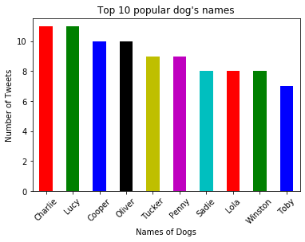

```python
fav_names.plot(kind='bar',color= my_colors).set(title="Top 10 popular dog's names", xlabel="Names of Dogs",ylabel="Number of Tweets")
plt.xticks(rotation=45);
```

Looking at the above chart, we know 'Charlie', 'Lucy','Cooper', and 'Oliver' are the most popular names for dogs among all the tweets from WeRateDogs.

#### 2. What is the most common dog's type (doggo, floofer, pupper and puppo)?

```python
fav_types=df_twitter.TypeOfDog.value_counts()
```

```python
fav_types
```

```
pupper     221
doggo      81
puppo      24
floofer    10
Name: TypeOfDog, dtype: int64
```

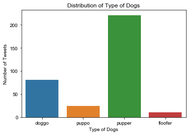

```python
ax=sns.countplot(x='TypeOfDog',data=df_twitter).set(title="Distribution of Type of Dogs", xlabel="Type of Dogs",ylabel="Number of Tweets")
sns.set(style="darkgrid");
```

```python
tweets_type=len(df_twitter[df_twitter['TypeOfDog'] == 'doggo'])+len(df_twitter[df_twitter['TypeOfDog']=='puppo'])+len(df_twitter[df_twitter['TypeOfDog']=='pupper'])+len(df_twitter[df_twitter['TypeOfDog']=='floofer'])
proportion= tweets_type/ len(df_twitter.TypeOfDog)*100
print ("Total number of tweets with Type of Dogs value: {}".format(tweets_type))
print ("Percentage of tweets: {}%".format(round(proportion,2)))
```

```
Total number of tweets with Type of Dogs value: 336
Percentage of tweets: 16.13%
```

Pupper is the type of dogs which has the most prevalent tweets and following up with doggo and puppo. Floofer seems to have the least tweets in twitter. However, there is a large portion of missing value in our data for 'TypeOfDog' column. We can only obtain 16% of the total tweets.

#### 3. What is the most common dog's breed?

```python
fav_breeds=df_twitter['Algorithm 1 Prediction'].value_counts().head(10)
```

```python
fav_breeds
```

```
Golden_retriever      136
Labrador_retriever    91
Pembroke              88
Chihuahua             78
Pug                   54
Chow                  41
Samoyed               40
Pomeranian            38
Toy_poodle            37
Malamute              29
Name: Algorithm 1 Prediction, dtype: int64
```

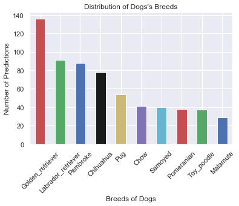

```python
fav_breeds.plot(kind='bar',color= my_colors).set(title="Distribution of Dogs's Breeds", xlabel="Breeds of Dogs",ylabel="Number of Predictions")
plt.xticks(rotation=45);
```

The top breeds of dogs are Golden_Retriever, Labrador_Retriever, Pembroke, and Chihuahua. Golden_Retriever has 136 tweets while the second popular breed Labrador_Retriever has 91 tweets following with 88 tweets of Pembroke. The gap between the second and the third breed of the popular list is not too big. There is only 3 tweets in difference. Chihuahua came as the fourth ranking in this list with 78 tweets.

#### 4. What is the most common used source of tweeting?

```python
df_twitter.source.value_counts()
```

```
Twitter for iPhone     1950
Vine - Make a Scene    91
Twitter Web Client     31
TweetDeck              11
Name: source, dtype: int64
```

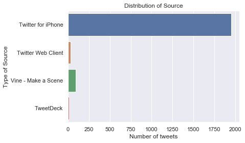

```python
sns.countplot(data=df_twitter,y='source').set(title="Distribution of Source", xlabel="Number of tweets",ylabel="Type of Source")
sns.set(style="darkgrid");
```

The chart above shows that the most of the tweets came from Twitter app for Iphone. The second popular channel that people use to tweet is Vine's Make-a-Scene app and Twitter Web Client. TweetDeck appears as unpopular source to use Twitter.

#### 5. Explore correlation between Retweets, Favorites, and Ratings?

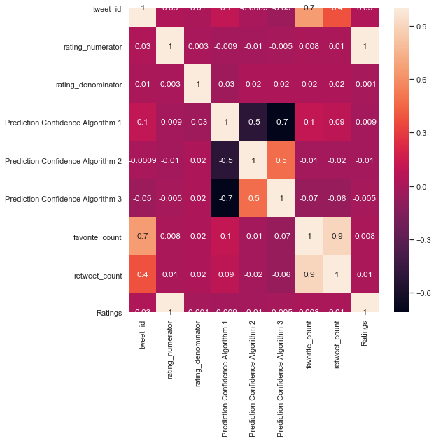

```python
fig, ax = plt.subplots(figsize=(8,8))
matrix=np.triu(df_twitter.corr())
sns.heatmap(df_twitter.corr(),annot=True,fmt='.1g');
```

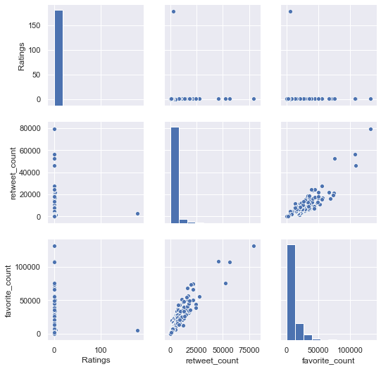

```python
sns.pairplot(df_twitter,vars=['Ratings','retweet_count','favorite_count']);
```

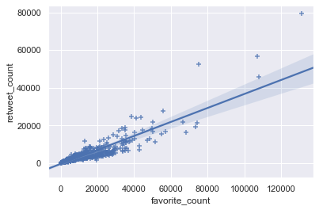

```python
ax=sns.regplot(x=df_twitter.favorite_count,y=df_twitter.retweet_count,marker="+");
```

Based on the plot above, we can visual there is a strong positive relationship between 'retweet_count' and 'favorite_count'. While there is not a clear correlation between 'Ratings'and the other variables.